# **EP07**

2022-10-06

#### **Lectura de Datos**

```r
datos <- read.csv("EP07 Datos.csv",header=TRUE, sep = ",")
```

## **Pregunta 1**

#### Filtrado de datos

```r
# Se setea la semilla 73
set.seed(73)
# Se filtran los datos y se obtienen instancias con 90 o más nodos
data_ancho_ej1 <- datos %>% filter(n.nodos >= 90)
```

#### Datos en formato largo

```r
# Obtención de muestra
filas <- sample(1:nrow(data_ancho_ej1),44)
TiempoA <- data_ancho_ej1$tiempo.A[1:24]
TiempoC <- data_ancho_ej1$tiempo.C[25:44]
Tiempo <- c(TiempoA, TiempoC)
Algoritmo <- c(rep("A",20),rep("C",24))
# Se obtienen los datos en formato largo
data_long_ej1 <- data.frame(Algoritmo,Tiempo)
```

### Histograma

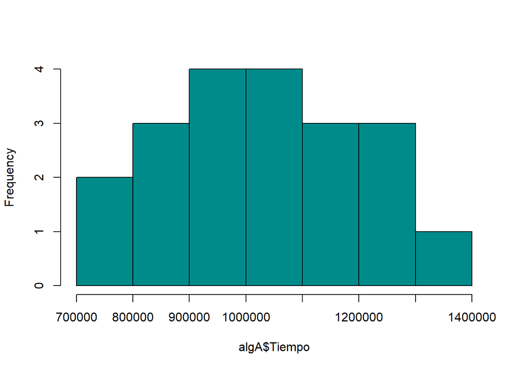

```r
# Se crea un histograma para complementar la información anterior
algA <- data_long_ej1 %>% filter(Algoritmo == "A")
algC <- data_long_ej1 %>% filter(Algoritmo == "C")
hist(algA$Tiempo, col = "cyan4", main = "")
```

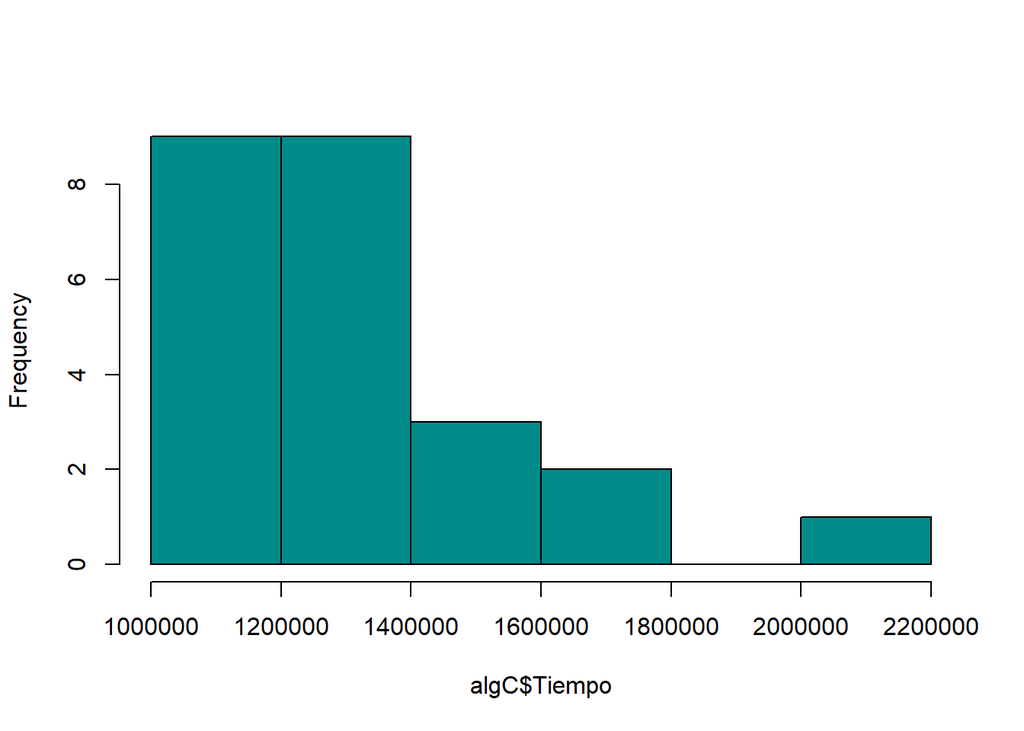

```r
hist(algC$Tiempo, col = "cyan4", main = "")
```

Cómo se puede observar en los histogramas, los datos son asimétricos, por lo que se usa el **Método de escalera de potencias de Tuckey** para transformarlos a una distribución simétrica cercana a la normal.

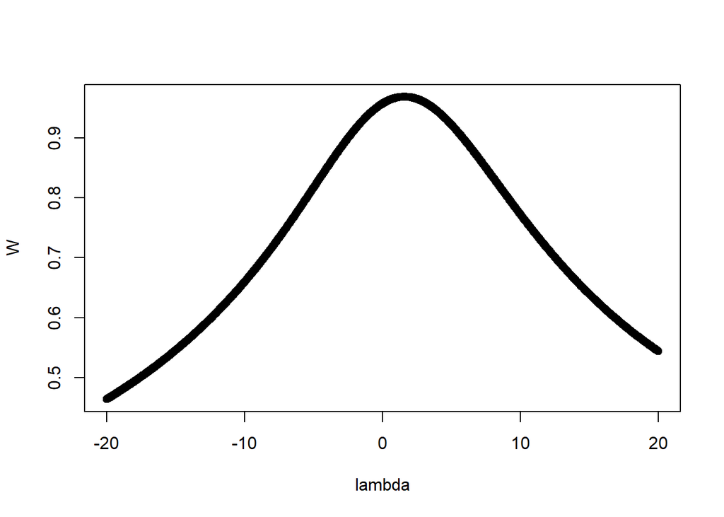

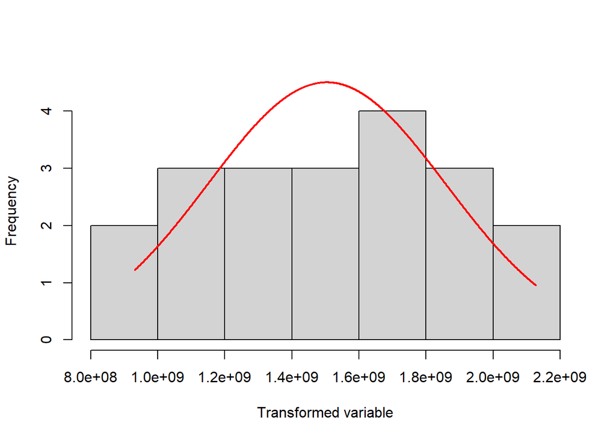

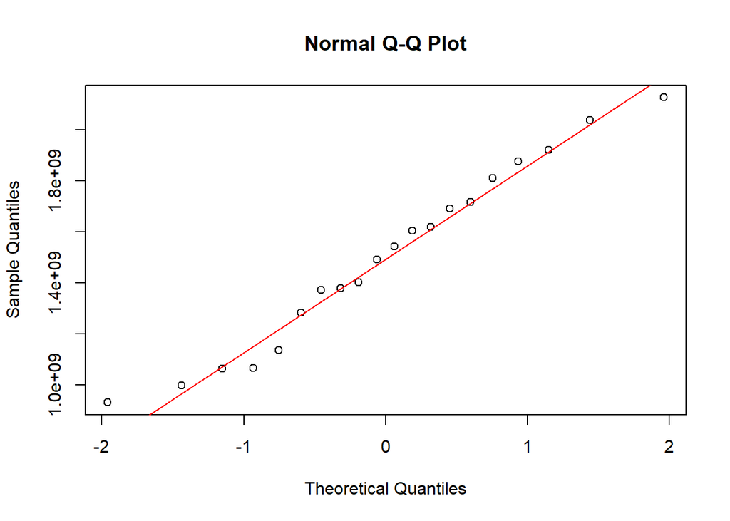

```r
# Se aplica el método de escalera de potencias de Tuckey a los algoritmos A y C
algA_tuckey <- transformTukey(algA$Tiempo,start = -20,end = 20,int = 0.025,plotit = TRUE,quiet=TRUE,statistic = 1)
```

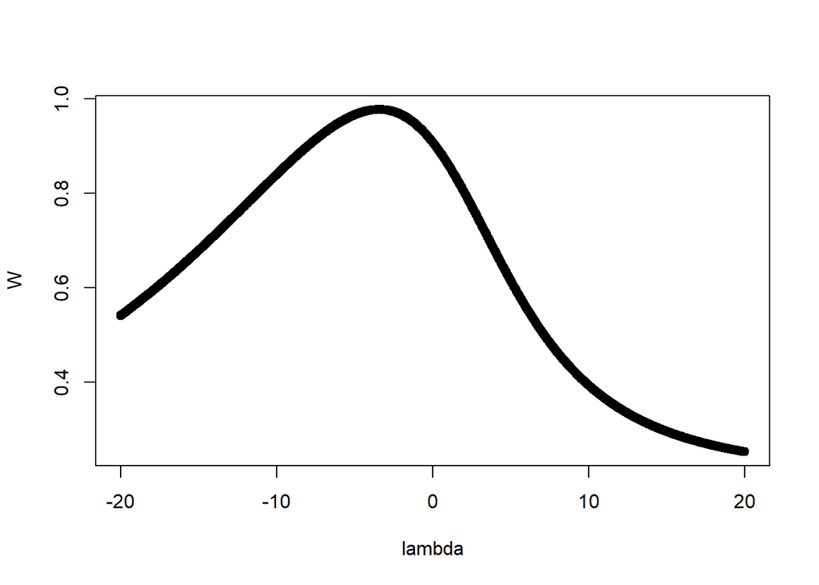

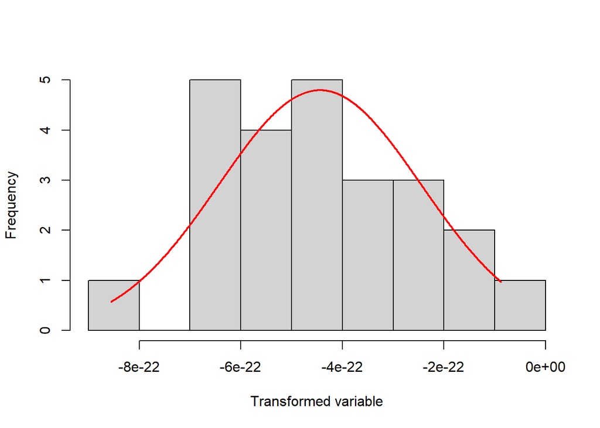

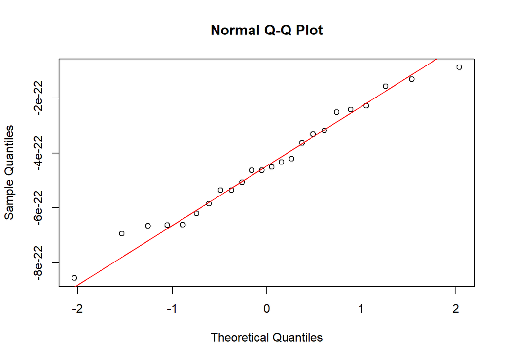

```r
algC_tuckey <- transformTukey(algC$Tiempo,start = -20,end = 20,int = 0.025,plotit = TRUE,quiet=TRUE,statistic = 1)
```

```r
# Se utiliza un nivel de confianza del 95%
alfa = 0.05
# Se aplica la prueba T con los datos arreglados
t_test <- t.test(Tiempo ~ Algoritmo, data_long_ej1, conf.level = 1 - alfa)
print(t_test)
```

```
##
##  Welch Two Sample t-test
##
## data:  Tiempo by Algoritmo
## t = -4.8191, df = 40.627, p-value = 2.04e-05
## alternative hypothesis: true difference in means between group A and group C is not equal to 0
## 95 percent confidence interval:
##  -413008.5 -169025.2
## sample estimates:
## mean in group A mean in group C
##         1035635         1326652
```

[output not shown]

## **Pregunta 2**

#### **La memorista también sospecha que, al comparar las mismas instancias, las mejores soluciones encontradas por las versiones A y B tienen rendimientos distintos. ¿Estará en lo cierto? Para responder, seleccionen las columnas con el mejor rendimiento de las versiones A y B en formato ancho. Usando como semilla el valor 13, obtengan una muestra aleatoria de 22 instancias. Lleven los datos a formato largo y utilicen una prueba no paramétrica apropiada para analizar las muestras obtenidas.**

#### Filtrado de datos

```r
# Se setea la semilla solicitada
set.seed(13)
# Se filtran los datos y se obtienen instancias con 90 o más nodos
data_ancho_ej2 <- datos %>% filter(n.nodos >= 90)
```

#### Datos en formato largo

```r
filas <- sample(1:nrow(data_ancho_ej2),22)
Mejor_A <- data_ancho_ej2$mejor.A[filas]
Mejor_B <- data_ancho_ej2$mejor.B[filas]
Instancia <- data_ancho_ej2$instancia[filas]
Algoritmo <- c(rep("A",22),rep("B",22))
Mejor <- c(Mejor_A,Mejor_B)

# Se obtienen los datos en formato largo
data_long_ej2 <- data.frame(Instancia,Algoritmo,Mejor)
```

### Histograma

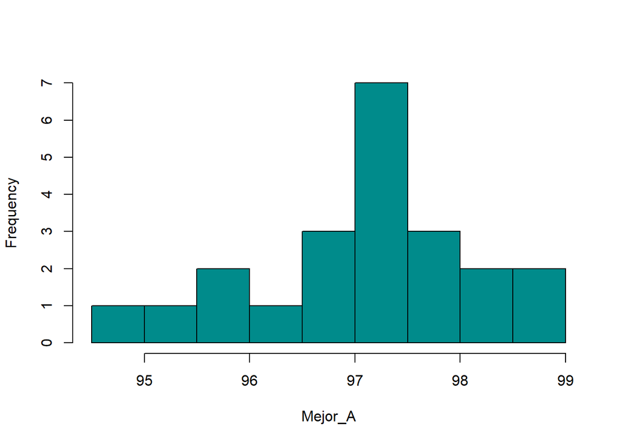

```r
# Se crea un Histograma para visualizar la información y el comportamiento de los datos
hist(Mejor_A, col = "cyan4", main = "")
```

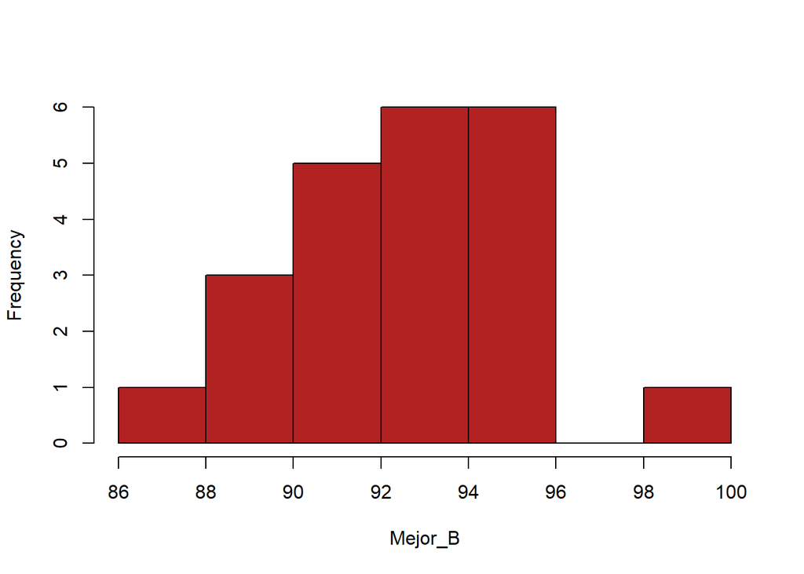

```r
hist(Mejor_B,col = "firebrick", main = "")
```

Cómo se puede observar el tamaño de grupos es pequeño, y presentan una asimetría en el histograma, por lo tanto no es posible utilizar una prueba paramétrica cómo **t-test** de muestras pareadas, nuestra alternativa más cercana es **La prueba de los rangos con signo de Wilcoxon**, ya que por cada observación o instancia tenemos 2 componentes (mejor tiempo algoritmo A y mejor tiempo algoritmo B)

### Boxplot

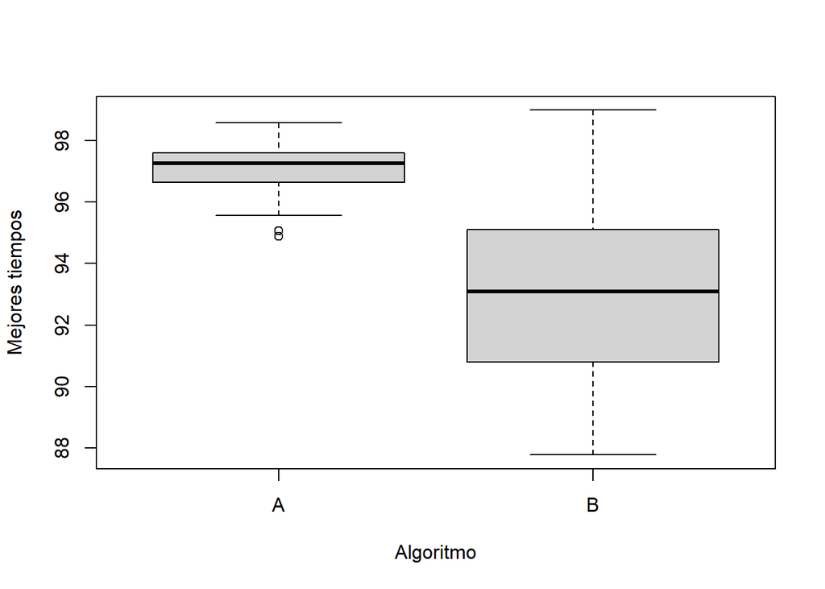

```r
# Se crea un diagrama de caja de ambos algoritmos y los mejores tiempos
boxplot(Mejor ~ Algoritmo, data_long_ej2, names=c("A","B"),xlab="Algoritmo", ylab = "Mejores tiempos")
```

### Condiciones Prueba de los rangos con signo de Wilcoxon

- Las observaciones de ambas muestras son pareadas: Las observaciones fueron extraídas aleatoriamente, ya que se usa la función sample para extraer x muestras de forma aleatoria.
- La escala empleada para las observaciones debe ser intrínsecamente continua: Esto es así, dado que al tratarse de tiempos se puede decir que un valor tiempo puede tomar infinitos valores en un intervalo.
- La escala de medición empleada para ambas muestras debe ser a lo menos ordinal: Se cumple, dado que al tratarse de tiempos se puede concluir y decir que un tiempo es mejor que otro, igual o peor que otro.

### Definición de hipótesis

Las hipótesis a tener en consideración son:

- $H_0$: **No hay diferencia en los rendimientos entre las mejores soluciones encontradas por A y B**
- $H_A$: **Hay diferencia en los rendimientos entre las mejores soluciones encontradas por A y B**

### Aplicación de la prueba

```r
# Considerando el enunciado y los datos, utilizaremos un alfa igual a 0.05. (Nivel de confianza del 95%)
alfa <- 0.05
# Se aplica la prueba de rangos con signos de Wilcoxon
wilcox_test <- wilcox.test(Mejor ~ Algoritmo,data = data_long_ej2,paired = TRUE, alternative = "two.sided",conf.level = 1 - alfa)
print(wilcox_test)
```

```
##
##  Wilcoxon signed rank exact test
##
## data:  Mejor by Algoritmo
## V = 250, p-value = 2.384e-06
## alternative hypothesis: true location shift is not equal to 0
```

[output not shown]

Lo anterior también puede responder a la interrogante de la pregunta: **La memorista está en lo cierto**, pues mediante el análisis hecho anteriormente se puede comprobar que las mejores soluciones encontradas por las versiones A y B tienen rendimientos distintos.